```r
param <- list(n = 100, m = 5)
```

## The student's Q–Q plotting function

The `plot.ls` function defined below uses `qqmath` of the lattice package to produce a trellis plot, where each panel is the normal Q–Q plot of one sample from the sequence of samples `s`. Our `plot.ls` expects `s` to be implemented as an unnamed list of named lists. Each named list has an element named `family` that specifies the family of the distribution, an element named `sample` that contains the sample points, and an element named `i` that specifies the index of the distribution in the sequence.

If `guess` argument is `FALSE`, then `plot.ls` will display the name of the distribution family on the top of each panel. Otherwise the student must guess the families. In the latter case she/he can check the answers by printing the return value of `plot.ls`. A few more details on `plot.ls` will be given later.

```r
plot.ls <- function(s, guess = FALSE, call2strip = FALSE, ...) {
    dt <- do.call(rbind, lapply(s, data.frame))
    d.names <- sapply(s, getElement, "family")
    tp <-
        qqmath(~ sample | i, data = dt,
               strip = strip.custom(factor.levels = d.names),
               strip.left =
                   if(call2strip)
                       strip.custom(factor.levels = sapply(s, getElement, "call"), par.strip.text = list(cex = 0.65))
                   else FALSE,
                   xlab = "normal quantiles", ylab = "sample quantiles", as.table = TRUE, between = list(x = 1, y = 1),
                   abline = c(0, 1), pch = "+",
                   ...)
    if(guess) tp <- update(tp, strip = strip.custom(factor.levels = as.character(seq_along(s))),
                           strip.left = FALSE, main = "Guessing distributions")
    print(tp)
    if(guess) d.names
}
```

## The teacher's sampling function using “switch”

`sample.d.switch` specifies four distributions. Each distribution is represented as a named list with the `family`, `sample` and `i` components mentioned above. The unnamed list of these named lists appears the (unnamed) list of “alternatives” passed `switch` in the body of `sample.d.switch`. The arguments of `sample.d.switch` itself are `x` and `p`. The `x` argument is a sequence of possibly repeated indices of arbitrary length; each index selects one of the four distributions specified within `switch` therefore must range between 1 and 4. The `p` argument contains information on sample sizes and parameter values, and defaults to the `param` list defined above.

```r
sample.d.switch <- function(x = 1:4, p = param) {
    n <- p$n
    m <- p$m
    helper <- function(i) {
        switch(x[i],
               list(family = "normal", sample = rnorm(n), i = factor(i)),
               list(family = "t", sample = rt(n, df=m), i = factor(i)),
               list(family = "gamma", sample = rgamma(n, shape=m) / m, i = factor(i)),
               list(family = "rounded.normal", sample = round(m * rnorm(n)) / m, i = factor(i)))
    }
    lapply(seq_along(x), helper)
}
```

Let's see how the teacher generates a sequence `s` of samples using `sample.d.switch`! She/he decides to pass the default `x = 1:4` argument, which results in the original sequence of four unique (not repeated) distributions.

```r
set.seed(1993) # the year R appeared
str(s <- sample.d.switch(x = 1:4))
```

```
## List of 4
##  $ :List of 3
##   ..$ family: chr "normal"
##   ..$ sample: num [1:100] -0.5005 -0.3772 0.0435 -0.6507 1.1533 ...
##   ..$ i     : Factor w/ 1 level "1": 1
##  $ :List of 3
##   ..$ family: chr "t"
##   ..$ sample: num [1:100] -1.074 1.623 -0.817 0.934 -0.133 ...
##   ..$ i     : Factor w/ 1 level "2": 1
##  $ :List of 3
##   ..$ family: chr "gamma"
##   ..$ sample: num [1:100] 0.47 0.819 0.98 0.566 1.206 ...
##   ..$ i     : Factor w/ 1 level "3": 1
##  $ :List of 3
##   ..$ family: chr "rounded.normal"
##   ..$ sample: num [1:100] 0.4 0.2 -0.8 0.6 1.8 0.6 0 -0.2 0 0.6 ...
##   ..$ i     : Factor w/ 1 level "4": 1
```

The teacher tells the student to first plot the sequence of samples with `plot.ls` and display the families as well so that the student can analyze their shapes before having to solve the “real” exercise: the reverse task, that is.

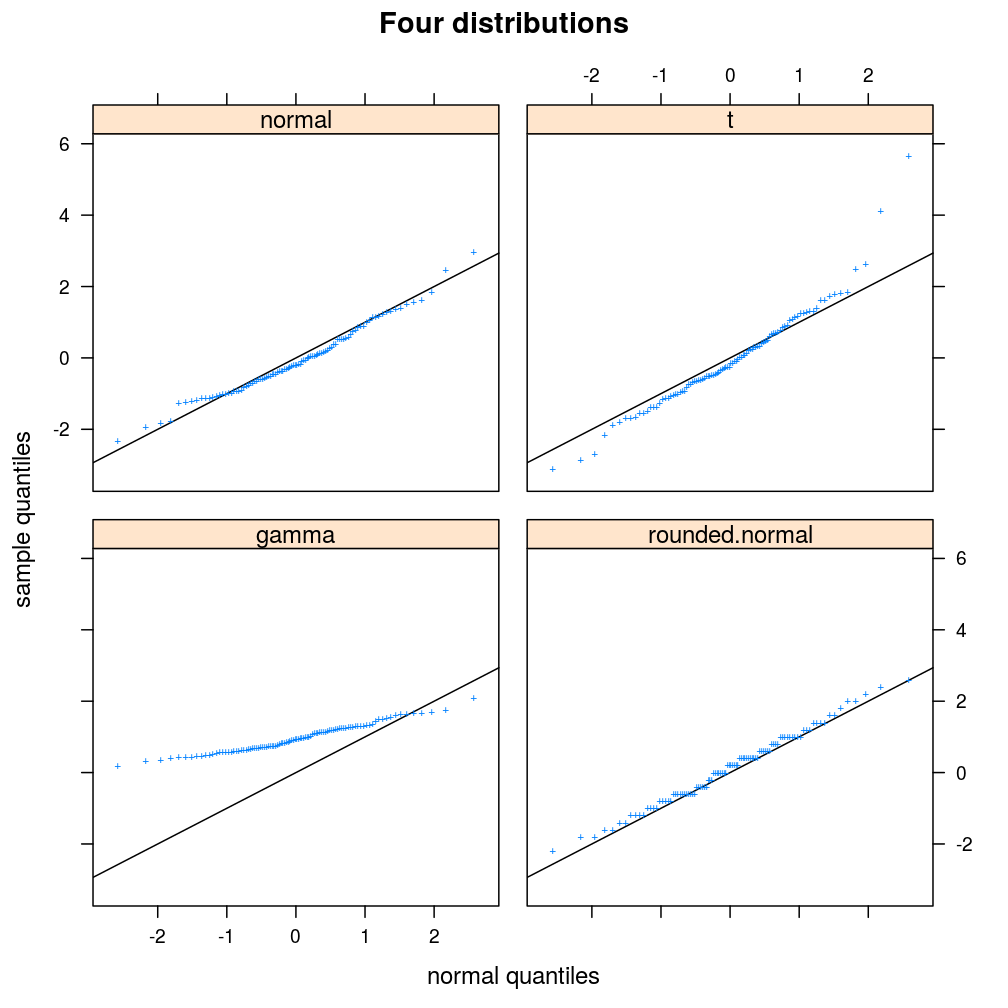

```r
library(lattice)
plot.ls(s = s, guess = FALSE, main = "Four distributions")
```

The student notes that, relative to the standard normal distribution, the t distribution has heavier tails, the gamma distribution is not supported on negative numbers, and that the effect of rounding is a step-like pattern in the Q–Q plot.

Now the teacher challenges the student with a sequence of six samples, three of which (#2, #3, #5) are from the t distribution, two (#4, #6) from the normal distribution and one (#1) from the gamma.

```r
s <- sample.d.switch(x = c(3, 2, 2, 1, 2, 1))
```

When the student plots these samples with `guess = TRUE`, this is what she/he sees:

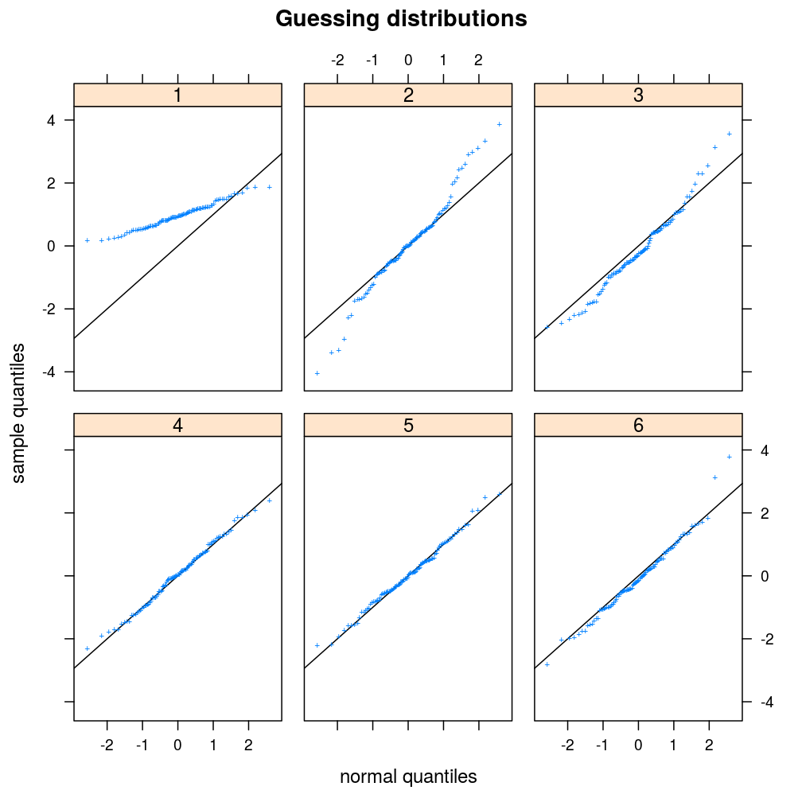

```r
library(lattice)
ans <- plot.ls(s = s, guess = TRUE)
```

Once she/he guessed the distributions, the correct answers are printed.

```r
ans
```

```
## [1] "gamma"  "t"      "t"      "normal" "t"      "normal"
```

## The teacher's sampling function using “substitute”

The teacher is dissatisfied by two limitations of `sample.d.switch`.

The second limitation is the lack of modularity that follows from the fact that the set of four distinct distributions are tied to the body of `sample.d.switch`. How can more distinct distributions be added to the exercise without changing the body of the sampling function?

So, the teacher implements `sample.d.substitute`. The `x` and `p` arguments have the same semantics as in the case of `sample.d.switch`. The new argument is `ld`, the unnamed list of named lists.

```r
sample.d.substitute <- function(x = 1:4, ld, p = param) {
    helper <- function(i) {
        le <- list(e = ld[[x[i]]])
        cl <- eval(substitute(substitute(e, p), le))
        list(family = names(ld[x[i]])[[1]],
             call = deparse(cl),
             sample = eval(cl),
             i = factor(i))
    }
    lapply(seq_along(x), helper)
}
```

Now the set of four distinct distributions can be stored in a `l.distr`, a list of lists, which exists separately from `sample.d.substitute`.

```r
l.distr <- list(normal = quote(rnorm(n = n)),
                t = quote(rt(n = n, df = m)),
                gamma = quote(rgamma(n = n, shape = m) / m),
                rounded.normal = quote(round(m * rnorm(n = n)) / m))
```

But before the teacher tests `sample.d.substitute` she/he decides to add two more distinct distributions to `l.distr`.

```r
# extend list of distributions
l.distr$beta <- quote((rbeta(n = n, shape1 = m, shape2 = m) - 0.5) * m)
l.distr$normal.cauchy.mix <- quote(c(rnorm(n = n - m), rcauchy(n = m)))
```

Now, the system is ready for the test.

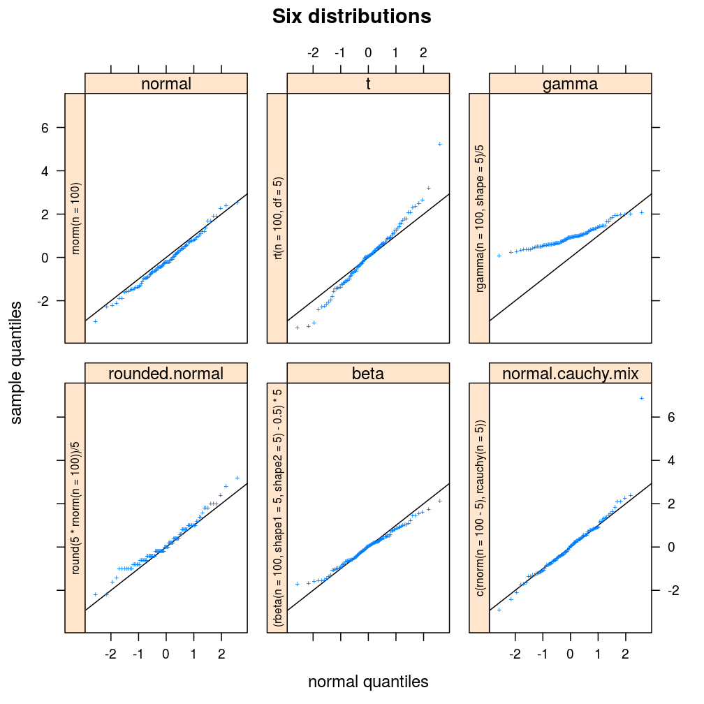

```r
s <- sample.d.substitute(x = 1:6, ld = l.distr)
plot.ls(s = s, guess = FALSE, call2strip = TRUE, main = "Six distributions")
```

The teacher likes `sample.d.substitute` so much that she/he starts exercising with it.

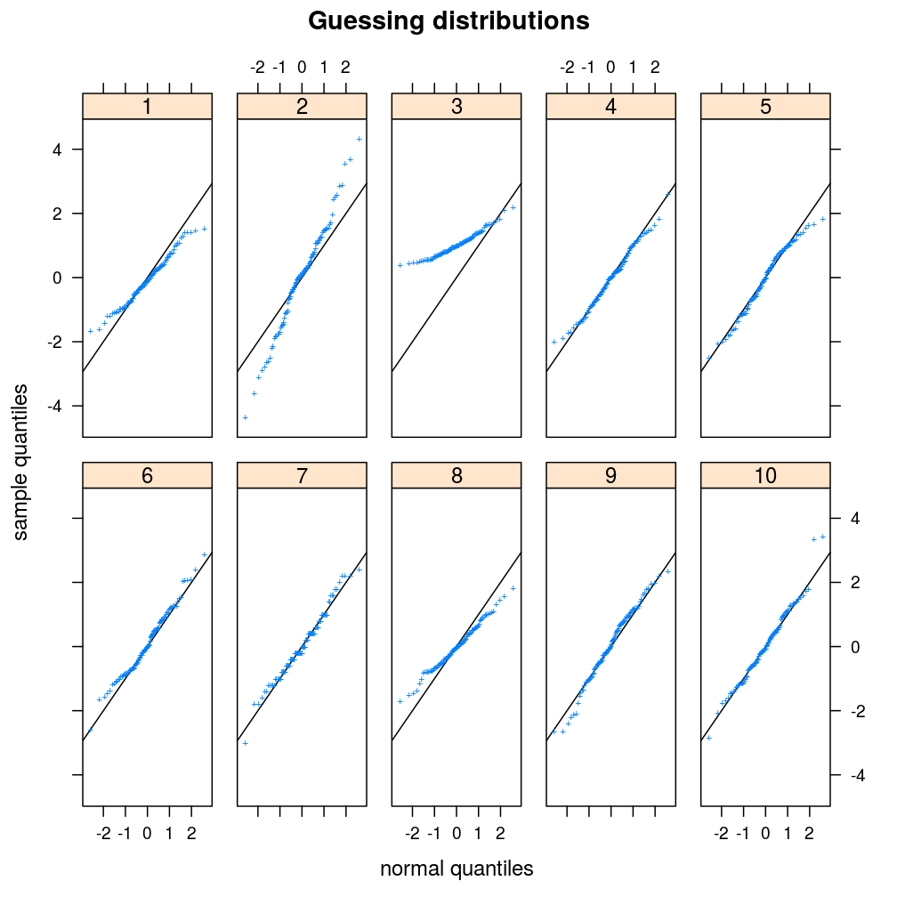

```r
set.seed(13) # challenging superstition
s <- sample.d.substitute(sample(seq_along(l.distr), 10, replace = TRUE), ld = l.distr)
ans <- plot.ls(s = s, guess = TRUE, layout = c(5, 2))
```

Checking answers:

```r
ans
```

```
##  [1] "beta"              "t"                 "gamma"
##  [4] "normal"            "normal.cauchy.mix" "normal"
##  [7] "rounded.normal"    "beta"              "normal.cauchy.mix"
## [10] "normal"
```

## Why substitution works better

Comparing the code for `sample.d.substitute` with that of `sample.d.switch` shows, that the main change was the replacement of the `switch` expression by several expressions that involve two calls to `substitute` and two calls to `eval`. Let's look at the most relevant part of the code of `sample.d.substitute`!

```r
1   sample.d.substitute <- function(x = 1:4, ld, p = param) {
2       ....
3           le <- list(e = ld[[x[i]]])
4           cl <- eval(substitute(substitute(e, p), le))
5           ....
6                call = deparse(cl),
7                sample = eval(cl),
                 ....
        ....
```

Note that argument `ld` in line 1 is a list of `quote`d (that is: unevaluated) expressions like `rnorm(n = n)`. In line 3 a single expression is selected from `ld` using the index `x[i]` and that expression is named `e` within the named list `le`. So, if `x[i]` takes the value of `1` then `e` is `rnorm(n = n)` while if `x[i]` is, say, `6` then `e` is `c(rnorm(n = n - m), rcauchy(n = m))`.

Line 4 `eval`uates `substitute(substitute(e, p), le)` in multiple steps. First, the outer `substitute` replaces `e` by the value of `le$e`, which is the unevaluated expression `c(rnorm(n = n - m), rcauchy(n = m))` if we select the 6th element of `l.distr`. We assign the value of the first substitute to `s1` so that we can print it:

```r
# p and le in the workspace instead of the body of sample.d.substitute
p <- list(n = 77, m = 4)
le <- list(e = l.distr[[6]])
(s1 <- substitute(substitute(e, p), le))
```

```
## substitute(c(rnorm(n = n - m), rcauchy(n = m)), p)
```

Now the second substitution takes place that replaces the *second* `n` in the argument list of `rnorm` with the value of `n` in the named list `list(n = 77, m = 4)`, which is `77`. It does *not* replace the first `n` symbol in `rnorm` neither the only `n` symbol in `rcauchy` because both of those instances of the `n` symbol stand for the *name* of these functions' sample size argument (in scheme they are called formal parameters). Such complication does not arise with `m` because that symbol identifies no argument name in `rnorm` or `rcauchy`, so both instances of `m` are replaced with `4`. But the second substitution cannot occur without `eval` because `substitute(c(rnorm(n = n - m), rcauchy(n = m)), p)`, the value of `s1`, is an unevaluated expression just like `rnorm(n = n)` and the others in `l.distr`. In this sense it does not matter that the value of `s1` happens to contain the symbol `substitute` while `rnorm(n = n)` does not; both expressions are unevaluated until passed to `eval`. When this happens to `s1`, only then does it gain significance that `s1` names an expression that begins with `substitute`. Evaluation of such expression results in a new unevaluated expression with all the replacements, concerning symbols in `p`, having taken place.

```r
(cl <- eval(s1))
```

```
## c(rnorm(n = 77 - 4), rcauchy(n = 4))
```

This expression is specific both to the index of `l.distr`, in this case `6`, and to the value of `p`, in this case `list(n = 77, m = 4)`. The two substitutions were necessary to *isolate* the specification of the family of the distribution from the specification of its parameters.

Now we can do two things with the unevaluated expression `cl`, which is formally a call object. First, as in line 6 above, we can `deparse` it into a character vector to use it in various figure labels.

```r
deparse(cl)
```

```
## [1] "c(rnorm(n = 77 - 4), rcauchy(n = 4))"
```

Second, as in line 7 above, we can evaluate it to generate the statistical sample, implemented as a numeric vector.

```r
str(eval(cl))
```

```
##  num [1:77] -0.621 -0.214 -0.506 0.93 -0.913 ...
```

`cl` is used in both ways in `sample.d.substitute` and that is one of the reasons why that function is superior to `sample.d.switch`. The other reason is the modularity enabled by the passing of unevaluated expressions (e.g. `rnorm(n = n)`) to `sample.d.substitute`. The cost of this implementation is having to deal with the non-standard way of evaluation, which is more difficult to analyze and debug for most programmers who are already well accustomed to the standard evaluation in R.